# Chapter 2 Descriptives

Mia Charifson

2024-04-01

Last updated on: 2024-07-08.

# Chapter Two

This is an R Markdown document which documents the following:

1. The final analytic and complete case sample size for Chapter 2
2. Descriptive statistics for Chapter 2
3. Exploratory descriptive statistics

```r
uf_cohort <- read.csv('Data/Derived/uf_all_hints.csv')
endo_cohort <- read.csv('Data/Derived/endo_all_hints.csv')
updated_cases <- read.csv('Data/Derived/final_cohort_w_outcome.csv')
false_negatives <- read.csv('Data/Derived/putative_false_negatives.csv')
covars <- read.csv('Data/Derived/clean_covariates.csv')
pat_cohort <- read.csv('Data/Derived/pat_cohort_w_censoring.csv')
ttd_symptoms <- read.csv('Data/Derived/Chapter 2/pat_cohort_w_ttd.csv')
ttd_symptoms_all_cases <- read.csv('Data/Derived/Chapter 2/pat_cohort_w_ttd_all_cases.csv')
pat_symptom_status <- read.csv('Data/Derived/Chapter 2/pat_cohort_symptom_status.csv')
address <- read.csv('Data/Derived/Chapter 1/pat_cohort_w_address.csv',
                    colClasses = c(census_tract_final = "character",
                                   full_fips_tract_final = "character"))
ever_proc_info <- read.csv('Data/Derived/Chapter 1/cohort_w_uf.csv')
```

```r
pat_w_covars <- pat_cohort %>%
  select(pat_id, index_enc_date, last_enc_date, all_provider_specialty, age_20160801, hcu_baseline,
         hcu_fu, site_baseline, site_fu, insur_status, insur_status_filled, obgyn_care_cohort) %>%
  rename(index_provider_specialty = all_provider_specialty) %>%
  left_join(covars %>% select(pat_id, employ_simple_final, race_final, ethnicity_final, race_ethnic_final,
                              HC_status, parity_binary, language_eng_sp, marital_status_final, bmi_baseline,
                              contains('adeno')),
            by='pat_id')
```

```r
pat_w_outcome <- ttd_symptoms %>%
  select(pat_id, contains('uf'), contains('endo'), final_outcome_status, final_censor_date,
         final_censor_type, contains('symptom'), contains('ttd')) %>%
  rename(time_to_dx = ttd,
         time_to_dx_2symptoms = ttd_2)
```

## Final sample size

```r
# exclude those deemed confident prevalents
confident_prevalents <- rbind(uf_cohort %>% filter(confident_prevalent) %>% select(pat_id),
                              endo_cohort %>% filter(confident_prevalent) %>% select(pat_id)) %>%
  distinct(pat_id)

# exclude those who do not live in NYC or site_baseline == 'Florida'
not_in_nyc <- address %>%
  filter(addr_NA_reason != 'Low accuracy score' & !is.na(addr_NA_reason)) %>%
  select(pat_id) %>%
  left_join(pat_w_covars %>% filter(site_baseline == 'FLORIDA') %>% select(pat_id), by='pat_id')

ch2_cohort <- pat_w_outcome %>%
  # remove if not disease free at baseline
  filter(!pat_id %in% confident_prevalents$pat_id) %>%
  # remove if they do not live in NY-Newark CSA? %>%
  filter(!pat_id %in% not_in_nyc$pat_id) %>%
  # join covariates
  left_join(pat_w_covars, by='pat_id') %>%
  mutate(included = case_when(final_outcome_status == 'Unconfirmed' ~'No',
                              TRUE~'Yes'),
         two_symptom_cohort = !is.na(time_to_dx_2symptoms) & included=='Yes')
```

```r
# Eligible cohort
print(paste0('Eligible patients: ', ch2_cohort %>% distinct(pat_id) %>% nrow()))
# How many were excluded based on site/address
print(paste0('Patients excluded based on site/address: ', not_in_nyc %>% distinct(pat_id) %>% nrow()))
# Included
print(paste0('Included patients: ', ch2_cohort %>% filter(included=='Yes') %>% nrow()))
# Has complete exposure data
print(paste0('Complete exposure data: ', ch2_cohort %>% filter(!is.na(race_ethnic_final) & !is.na(insur_status) & !is.na(language_eng_sp)) %>% nrow()))
# Is excluded due predictor status
print(paste0('Missing race/ethnicity: ', ch2_cohort %>% filter(is.na(race_ethnic_final)) %>% nrow()))
print(paste0('Missing insurance: ', ch2_cohort %>% filter(is.na(insur_status)) %>% nrow()))
print(paste0('Missing language: ', ch2_cohort %>% filter(is.na(language_eng_sp)) %>% nrow()))
# Symptom count
print(paste0('Has >=two symptoms: ', ch2_cohort %>% filter(two_symptom_cohort) %>% nrow()))
print(paste0('Excluded for having only one symptom: ', ch2_cohort %>% filter(!two_symptom_cohort & included=='Yes') %>%
               nrow()))
```

[output not shown]

Additional eligibility exclusions:

- all identified confident prevalent cases are excluded
- Not eligible (lived outside NYC, included Florida as baseline site)

Reasons for exclusions:

- Patient never reports a symptom
- Patient reports a symptom prior to index encounter
- Outcome could not be ascertained (hesitant cases)
- Missing exposure data (this will be imputed but still report number)
- Sensitivity analysis: Patient only reports one symptom during follow-up

```r
### Need to figure out how to make off shoots for excluded cases
### draw line from an edge to a node
DiagrammeR::grViz("digraph {
  graph [layout = dot, rankdir = TB]

  node [shape = rectangle]
  rec1 [label = 'Patients with symptom during follow-up (n=23,429)']
  rec2 [label = 'Complete Outcome Data (n=22,959)']
  rec3 [label = 'Final sample size (n=22,959)']
  rec4 [label = 'Reports at least two symptoms (n=19,436)']
  rec5 [label = 'Complete Exposure Data (n=19,436)']
  rec6 [label = 'Missing race/ethnicity (n=2,132)']
  rec7 [label = 'Missing insurance status (n=1,884)']
  rec8 [label = 'Missing preferred language (n=41)']
  rec9 [label = 'Excluded for lacking symptoms (n=49,249)']
  rec10 [label = 'Reported symptom prior to baseline (n=7,685)']
  rec11 [label = 'Never reported symptom (n=41,564)']
  # edge definitions with the node IDs
  rec1 -> rec2 -> rec3 -> rec4
  rec5 -> rec6 -> rec7 -> rec8
  rec9 -> rec10 -> rec11
  }", height = 500)
```

[interactive chart not shown]

```r
ch2_final <- ch2_cohort %>%
  filter(included=='Yes') %>%
  mutate(symptom_group = case_when(grepl('R10.2|F52.6|N94.1|N94.0|M54.5', first_symptom_icd10s)~'Pain',
                                  grepl('N94.[4-6]|N93.0|N93.8|N93.9|N92.0|N92.1|D50.0',
                                             first_symptom_icd10s)~'Menstrual/Bleeding',
                                  grepl('N83.0|N83.2|N73.9', first_symptom_icd10s)~'PID/Ovarian cysts',
                                  grepl('N97.9', first_symptom_icd10s)~'Infertility',
                                  grepl('N32.9|K59.00|N39.3|R19.7', first_symptom_icd10s)~
                                    'Other Genito-urinary')) %>%
  mutate(final_outcome_group = case_when(grepl('Both', final_outcome_status)~'Both',
                                         TRUE~final_outcome_status),
         time_to_dx_cat = case_when(time_to_dx < 6~'Under 6 months',
                                    time_to_dx >= 6 & time_to_dx < 12 ~'6-12 months',
                                    time_to_dx >= 12 & time_to_dx < 24 ~'12-48 months',
                                    time_to_dx >= 48 & time_to_dx < 60 ~'48-72 months',
                                    time_to_dx >= 72 ~'72+ months'),
         time_to_dx_cat = factor(time_to_dx_cat, levels = c('Under 6 months', '6-12 months',
                                                            '12-48 months', '48-72 months',
                                                            '72+ months')))

write.csv(ch2_final, 'Data/Derived/Chapter 2/final_dataset_20240516.csv', row.names = FALSE)

## Sample flags
ch2_sample <- pat_cohort %>%
  filter(!pat_id %in% confident_prevalents$pat_id) %>%
  left_join(ch2_cohort %>% select(pat_id, included, symptom_count, two_symptom_cohort), by='pat_id') %>%
  mutate(ch2_main = ifelse(included=='Yes', TRUE, FALSE),
         ch2_obgyn_cohort = ifelse(included=='Yes' & obgyn_care_cohort, TRUE, FALSE),
         ch2_all_cases = ifelse(pat_id %in% ttd_symptoms_all_cases$pat_id & !pat_id %in% not_in_nyc$pat_id, TRUE, FALSE),
         ch2_two_symptoms = ifelse(two_symptom_cohort, TRUE, FALSE)) %>%
  select(pat_id, contains('ch2'))

write.csv(ch2_final, 'Data/Derived/Chapter 2/sample_flags_20240529.csv', row.names = FALSE)
```

## Descriptive statistics

### Outcome: Time to diagnosis

#### First Symptom Group & Timing

```r
summary(tableby(~time_to_dx + symptom_group + final_outcome_group + symptom_count, data=ch2_final),
        labelTranslations = list(time_to_dx = 'Time from Symptom to Censor (months)',
                                 symptom_group = 'First Symptom Group',
                                 final_outcome_group = 'Outcome Group',
                                 symptom_count = 'Symptom Count'))
```

|  | Overall (N=22959) |
| --- | --- |
| **Time from Symptom to Censor (months)** |  |
| Mean (SD) | 45.124 (25.556) |
| Range | 0.033 - 85.200 |
| **First Symptom Group** |  |
| Infertility | 820 (3.6%) |
| Menstrual/Bleeding | 11405 (49.7%) |
| Other Genito-urinary | 1279 (5.6%) |
| Pain | 7473 (32.5%) |
| PID/Ovarian cysts | 1982 (8.6%) |
| **Outcome Group** |  |
| Both | 331 (1.4%) |
| Incident Endo only | 495 (2.2%) |
| Incident UF only | 2895 (12.6%) |
| Neither | 19238 (83.8%) |
| **Symptom Count** |  |
| Mean (SD) | 5.956 (8.311) |
| Range | 1.000 - 380.000 |

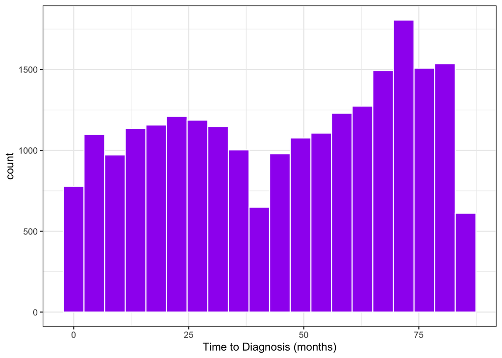

```r
ggplot(aes(x=time_to_dx), data=ch2_final) +
  geom_histogram(bins=20, fill = 'purple', color='white') +
  xlab('Time to Diagnosis (months)') +
  theme_bw()
```

#### TTD by First Symptom Group

```r
summary(tableby(final_outcome_group~time_to_dx, data=ch2_final,
                numerics.stats=c('Nmiss', 'N', 'meansd', 'median', 'q1q3')),
        labelTranslations = list(time_to_dx = 'Time from Dx or Censor (months)'))
```

|  | Both (N=331) | Incident Endo only (N=495) | Incident UF only (N=2895) | Neither (N=19238) | Total (N=22959) | p value |
| --- | --- | --- | --- | --- | --- | --- |
| **Time from Dx or Censor (months)** |  |  |  |  |  | 0.009 |
| Mean (SD) | 40.657 (27.271) | 46.354 (27.891) | 45.351 (26.478) | 45.135 (25.315) | 45.124 (25.556) |  |
| Range | 0.200 - 85.167 | 0.233 - 85.200 | 0.033 - 85.200 | 0.033 - 85.200 | 0.033 - 85.200 |  |

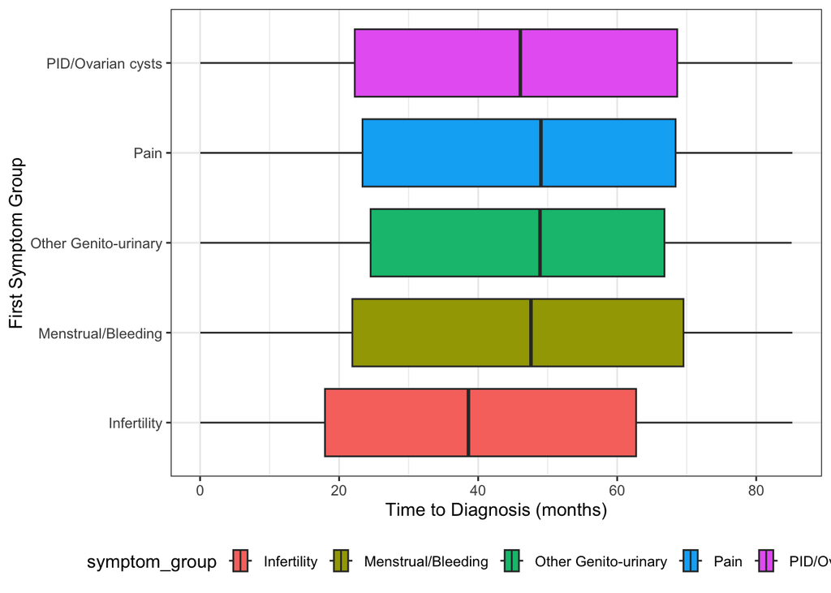

```r
ggplot(aes(x=time_to_dx, y=symptom_group, fill=symptom_group), data=ch2_final) +
  geom_boxplot() +
  ylab('First Symptom Group') +
  xlab('Time to Diagnosis (months)') +
  theme_bw() +
  theme(legend.position = 'bottom')
```

#### TTD by Outcome Status

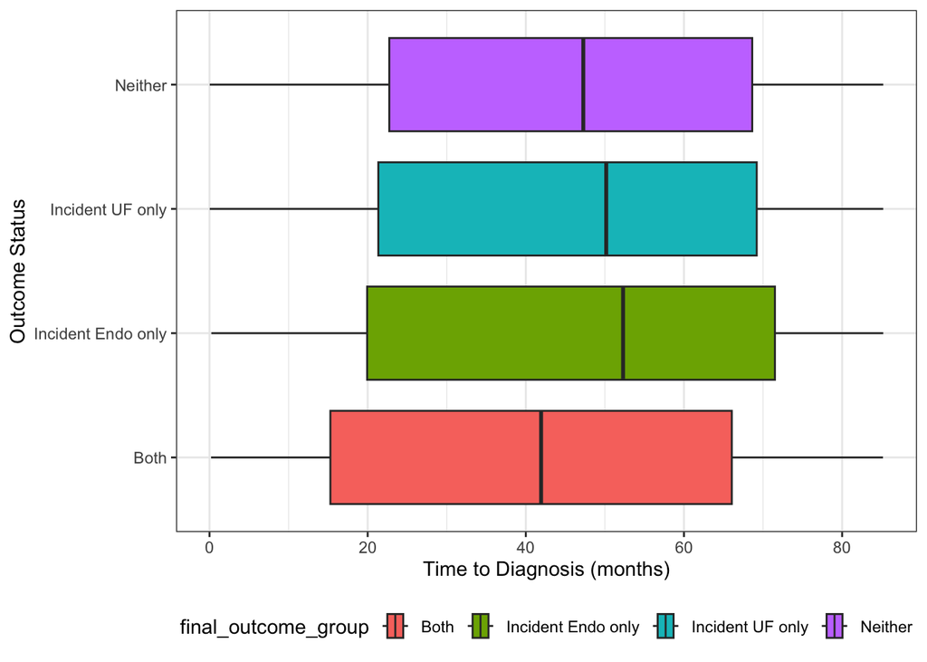

```r
ggplot(aes(x=time_to_dx, y=final_outcome_group, fill=final_outcome_group), data=ch2_final) +
  geom_boxplot() +
  ylab('Outcome Status') +
  xlab('Time to Diagnosis (months)') +
  theme_bw() +
  theme(legend.position = 'bottom')
```

#### {.unnumbered}

### Table 1: Cohort characteristics

```r
pat_labs <- list(hcu_baseline='Healthcare utilization (visits/baseline year)',
                 age_20160801='Age (years)',
                 HC_status='Hormonal contraceptive use',
                 parity_binary='Parity status',
                 marital_status_final='Relationship status',
                 bmi_baseline='Body mass index (kg/m^2)',
                 adeno_fu = 'Adenomyosis dx during FU',
                 adeno_baseline = 'Adenomyosis dx at baseline')

# patient information
summary(tableby(~hcu_baseline+age_20160801+HC_status+parity_binary+marital_status_final+bmi_baseline+
                  adeno_fu + adeno_baseline,data=ch2_final), labelTranslations = pat_labs)
```

|  | Overall (N=22959) |
| --- | --- |
| **Healthcare utilization (visits/baseline year)** |  |
| Mean (SD) | 4.476 (4.691) |
| Range | 1.000 - 128.000 |
| **Age (years)** |  |
| Mean (SD) | 33.020 (8.970) |
| Range | 16.000 - 50.000 |
| **Hormonal contraceptive use** |  |
| FALSE | 17325 (75.5%) |
| TRUE | 5634 (24.5%) |
| **Parity status** |  |
| N-Miss | 5259 |
| nulliparous | 8649 (48.9%) |
| parous | 9051 (51.1%) |
| **Relationship status** |  |
| N-Miss | 1171 |
| Partnered | 8566 (39.3%) |
| Unpartnered | 13222 (60.7%) |
| **Body mass index (kg/m^2)** |  |
| N-Miss | 1185 |
| Mean (SD) | 26.160 (5.419) |
| Range | 11.340 - 41.660 |
| **Adenomyosis dx during FU** |  |
| FALSE | 22584 (98.4%) |
| TRUE | 375 (1.6%) |
| **Adenomyosis dx at baseline** |  |
| FALSE | 22949 (100.0%) |
| TRUE | 10 (0.0%) |

```r
ses_labs <- list(site_baseline='Most common care site (baseline)',
                 insur_status='Insurance type',
                 employ_simple_final='Employment status',
                 race_ethnic_final='Racial and Ethnic Group',
                 language_eng_sp='Preferred language')

# ses information
summary(tableby(~site_baseline+insur_status+employ_simple_final+race_ethnic_final+language_eng_sp,
                data=ch2_final), labelTranslations = ses_labs)
```

|  | Overall (N=22959) |
| --- | --- |
| **Most common care site (baseline)** |  |
| Brooklyn OP | 2621 (11.4%) |
| Family Health Centers at NYU | 5830 (25.4%) |
| Manhattan OP | 7973 (34.7%) |
| Nassau OP | 3811 (16.6%) |
| NYU Langone Brooklyn | 323 (1.4%) |
| Queens OP | 1054 (4.6%) |
| Staten Island OP | 860 (3.7%) |
| Telemedicine | 10 (0.0%) |
| Tisch/Manhattan Inpatient | 274 (1.2%) |
| Westchester OP | 203 (0.9%) |
| **Insurance type** |  |
| N-Miss | 1856 |
| private | 13384 (63.4%) |
| public | 7719 (36.6%) |
| **Employment status** |  |
| N-Miss | 6266 |
| Employed | 11320 (67.8%) |
| Not Employed | 4127 (24.7%) |
| Retired | 22 (0.1%) |
| Student | 1224 (7.3%) |
| **Racial and Ethnic Group** |  |
| N-Miss | 2083 |
| Hispanic/Latino | 6674 (32.0%) |
| NH Asian | 1611 (7.7%) |
| NH Black | 2840 (13.6%) |
| NH MENA | 20 (0.1%) |
| NH Multiple Races | 171 (0.8%) |
| NH native | 29 (0.1%) |
| NH NHPI | 16 (0.1%) |
| NH White | 9515 (45.6%) |
| **Preferred language** |  |
| N-Miss | 39 |
| English | 19511 (85.1%) |
| Other | 719 (3.1%) |
| Spanish | 2690 (11.7%) |

## Bivariate statistics

### Predictors-Outcome

Summary of observations – patients with longer time to diagonsis are/had:

- highest HCU use at baseline
- youngest
- most likely to use HC
- most likely to be nulliparous
- most likely to be unpartnered
- most likely to be at Nassau/Staten OP and FHC, least likely to be at Manhattan OP
- more likely to be a student/unemployed
- more likely to be Hispanic
- more likely to be a Spanish speaker

#### All patient characteristics

```r
summary(tableby(time_to_dx_cat~hcu_baseline+age_20160801+HC_status+parity_binary+
                  marital_status_final+bmi_baseline+adeno_fu + adeno_baseline, data=ch2_final),
        labelTranslations = pat_labs)
```

|  | Under 6 months (N=1705) | 6-12 months (N=1308) | 12-48 months (N=3156) | 48-72 months (N=3078) | 72+ months (N=4450) | Total (N=13697) | p value |
| --- | --- | --- | --- | --- | --- | --- | --- |
| **Healthcare utilization (visits/baseline year)** |  |  |  |  |  |  | < 0.001 |
| Mean (SD) | 4.150 (4.630) | 4.148 (5.085) | 4.143 (4.875) | 3.923 (4.092) | 6.070 (5.445) | 4.721 (4.989) |  |
| Range | 1.000 - 86.000 | 1.000 - 108.000 | 1.000 - 128.000 | 1.000 - 46.000 | 1.000 - 57.000 | 1.000 - 128.000 |  |
| **Age (years)** |  |  |  |  |  |  | < 0.001 |
| Mean (SD) | 34.430 (9.026) | 33.536 (9.000) | 32.892 (8.945) | 33.571 (8.901) | 31.841 (8.825) | 32.956 (8.955) |  |
| Range | 16.000 - 50.000 | 16.000 - 50.000 | 16.000 - 50.000 | 16.000 - 50.000 | 16.000 - 49.000 | 16.000 - 50.000 |  |
| **Hormonal contraceptive use** |  |  |  |  |  |  | < 0.001 |
| FALSE | 1336 (78.4%) | 1017 (77.8%) | 2396 (75.9%) | 2407 (78.2%) | 3086 (69.3%) | 10242 (74.8%) |  |
| TRUE | 369 (21.6%) | 291 (22.2%) | 760 (24.1%) | 671 (21.8%) | 1364 (30.7%) | 3455 (25.2%) |  |
| **Parity status** |  |  |  |  |  |  | < 0.001 |
| N-Miss | 432 | 344 | 789 | 729 | 854 | 3148 |  |
| nulliparous | 571 (44.9%) | 449 (46.6%) | 1175 (49.6%) | 1060 (45.1%) | 1895 (52.7%) | 5150 (48.8%) |  |
| parous | 702 (55.1%) | 515 (53.4%) | 1192 (50.4%) | 1289 (54.9%) | 1701 (47.3%) | 5399 (51.2%) |  |
| **Relationship status** |  |  |  |  |  |  | < 0.001 |
| N-Miss | 99 | 75 | 189 | 151 | 198 | 712 |  |
| Partnered | 639 (39.8%) | 495 (40.1%) | 1156 (39.0%) | 1201 (41.0%) | 1498 (35.2%) | 4989 (38.4%) |  |
| Unpartnered | 967 (60.2%) | 738 (59.9%) | 1811 (61.0%) | 1726 (59.0%) | 2754 (64.8%) | 7996 (61.6%) |  |
| **Body mass index (kg/m^2)** |  |  |  |  |  |  | 0.005 |
| N-Miss | 101 | 89 | 169 | 180 | 190 | 729 |  |
| Mean (SD) | 26.334 (5.347) | 25.875 (5.457) | 25.954 (5.409) | 26.383 (5.475) | 26.073 (5.347) | 26.129 (5.403) |  |
| Range | 15.800 - 41.600 | 14.950 - 41.660 | 14.360 - 41.570 | 14.480 - 41.660 | 13.710 - 41.640 | 13.710 - 41.660 |  |
| **Adenomyosis dx during FU** |  |  |  |  |  |  | 0.025 |
| FALSE | 1661 (97.4%) | 1291 (98.7%) | 3104 (98.4%) | 3033 (98.5%) | 4361 (98.0%) | 13450 (98.2%) |  |
| TRUE | 44 (2.6%) | 17 (1.3%) | 52 (1.6%) | 45 (1.5%) | 89 (2.0%) | 247 (1.8%) |  |
| **Adenomyosis dx at baseline** |  |  |  |  |  |  | 0.650 |
| FALSE | 1703 (99.9%) | 1308 (100.0%) | 3154 (99.9%) | 3077 (100.0%) | 4446 (99.9%) | 13688 (99.9%) |  |
| TRUE | 2 (0.1%) | 0 (0.0%) | 2 (0.1%) | 1 (0.0%) | 4 (0.1%) | 9 (0.1%) |  |

```r
summary(tableby(time_to_dx_cat~site_baseline+insur_status+employ_simple_final+
                  race_ethnic_final+language_eng_sp, data=ch2_final),
        labelTranslations = ses_labs)
```

|  | Under 6 months (N=1705) | 6-12 months (N=1308) | 12-48 months (N=3156) | 48-72 months (N=3078) | 72+ months (N=4450) | Total (N=13697) | p value |
| --- | --- | --- | --- | --- | --- | --- | --- |
| **Most common care site (baseline)** |  |  |  |  |  |  | < 0.001 |
| Brooklyn OP | 191 (11.2%) | 145 (11.1%) | 369 (11.7%) | 389 (12.6%) | 433 (9.7%) | 1527 (11.1%) |  |
| Family Health Centers at NYU | 430 (25.2%) | 310 (23.7%) | 672 (21.3%) | 822 (26.7%) | 1309 (29.4%) | 3543 (25.9%) |  |
| Manhattan OP | 688 (40.4%) | 534 (40.8%) | 1218 (38.6%) | 1069 (34.7%) | 1276 (28.7%) | 4785 (34.9%) |  |
| Nassau OP | 215 (12.6%) | 172 (13.1%) | 438 (13.9%) | 533 (17.3%) | 827 (18.6%) | 2185 (16.0%) |  |
| NYU Langone Brooklyn | 25 (1.5%) | 17 (1.3%) | 45 (1.4%) | 37 (1.2%) | 75 (1.7%) | 199 (1.5%) |  |
| Queens OP | 88 (5.2%) | 61 (4.7%) | 165 (5.2%) | 130 (4.2%) | 173 (3.9%) | 617 (4.5%) |  |
| Staten Island OP | 29 (1.7%) | 31 (2.4%) | 169 (5.4%) | 34 (1.1%) | 270 (6.1%) | 533 (3.9%) |  |
| Telemedicine | 1 (0.1%) | 0 (0.0%) | 0 (0.0%) | 5 (0.2%) | 0 (0.0%) | 6 (0.0%) |  |
| Tisch/Manhattan Inpatient | 19 (1.1%) | 20 (1.5%) | 39 (1.2%) | 36 (1.2%) | 50 (1.1%) | 164 (1.2%) |  |
| Westchester OP | 19 (1.1%) | 18 (1.4%) | 41 (1.3%) | 23 (0.7%) | 37 (0.8%) | 138 (1.0%) |  |
| **Insurance type** |  |  |  |  |  |  | < 0.001 |
| N-Miss | 142 | 102 | 231 | 264 | 374 | 1113 |  |
| private | 979 (62.6%) | 784 (65.0%) | 1949 (66.6%) | 1789 (63.6%) | 2468 (60.5%) | 7969 (63.3%) |  |
| public | 584 (37.4%) | 422 (35.0%) | 976 (33.4%) | 1025 (36.4%) | 1608 (39.5%) | 4615 (36.7%) |  |
| **Employment status** |  |  |  |  |  |  | < 0.001 |
| N-Miss | 468 | 355 | 1011 | 703 | 1264 | 3801 |  |
| Employed | 867 (70.1%) | 671 (70.4%) | 1482 (69.1%) | 1647 (69.3%) | 2066 (64.8%) | 6733 (68.0%) |  |
| Not Employed | 291 (23.5%) | 216 (22.7%) | 514 (24.0%) | 575 (24.2%) | 838 (26.3%) | 2434 (24.6%) |  |
| Retired | 4 (0.3%) | 1 (0.1%) | 2 (0.1%) | 3 (0.1%) | 3 (0.1%) | 13 (0.1%) |  |
| Student | 75 (6.1%) | 65 (6.8%) | 147 (6.9%) | 150 (6.3%) | 279 (8.8%) | 716 (7.2%) |  |
| **Racial and Ethnic Group** |  |  |  |  |  |  | < 0.001 |
| N-Miss | 170 | 120 | 346 | 258 | 358 | 1252 |  |
| Hispanic/Latino | 447 (29.1%) | 352 (29.6%) | 779 (27.7%) | 972 (34.5%) | 1445 (35.3%) | 3995 (32.1%) |  |
| NH Asian | 130 (8.5%) | 85 (7.2%) | 221 (7.9%) | 186 (6.6%) | 313 (7.6%) | 935 (7.5%) |  |
| NH Black | 230 (15.0%) | 175 (14.7%) | 395 (14.1%) | 397 (14.1%) | 488 (11.9%) | 1685 (13.5%) |  |
| NH MENA | 1 (0.1%) | 2 (0.2%) | 1 (0.0%) | 3 (0.1%) | 6 (0.1%) | 13 (0.1%) |  |
| NH Multiple Races | 16 (1.0%) | 9 (0.8%) | 19 (0.7%) | 29 (1.0%) | 25 (0.6%) | 98 (0.8%) |  |
| NH native | 5 (0.3%) | 0 (0.0%) | 3 (0.1%) | 2 (0.1%) | 9 (0.2%) | 19 (0.2%) |  |
| NH NHPI | 4 (0.3%) | 1 (0.1%) | 2 (0.1%) | 3 (0.1%) | 1 (0.0%) | 11 (0.1%) |  |
| NH White | 702 (45.7%) | 564 (47.5%) | 1390 (49.5%) | 1228 (43.5%) | 1805 (44.1%) | 5689 (45.7%) |  |
| **Preferred language** |  |  |  |  |  |  | < 0.001 |
| N-Miss | 6 | 2 | 9 | 2 | 5 | 24 |  |
| English | 1441 (84.8%) | 1122 (85.9%) | 2768 (88.0%) | 2591 (84.2%) | 3689 (83.0%) | 11611 (84.9%) |  |
| Other | 61 (3.6%) | 44 (3.4%) | 86 (2.7%) | 102 (3.3%) | 152 (3.4%) | 445 (3.3%) |  |
| Spanish | 197 (11.6%) | 140 (10.7%) | 293 (9.3%) | 383 (12.5%) | 604 (13.6%) | 1617 (11.8%) |  |

#### By insurance status

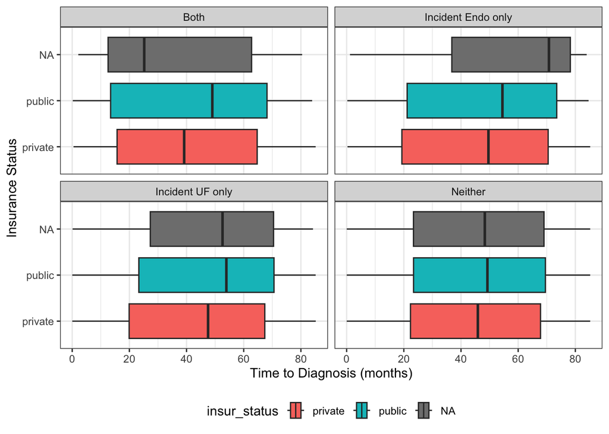

```r
ggplot(aes(x=time_to_dx, y=insur_status, fill=insur_status), data=ch2_final) +
  geom_boxplot() +
  ylab('Insurance Status') +
  xlab('Time to Diagnosis (months)') +
  facet_wrap(~final_outcome_group, nrow=2) +
  theme_bw() +
  theme(legend.position = 'bottom')
```

##### Among all patients

```r
summary(tableby(insur_status~time_to_dx, data=ch2_final,
                numeric.stats=c('Nmiss', 'N', 'meansd', 'median', 'q1q3')),
        labelTranslations = list(time_to_dx = 'Time to Dx or Censoring (months)'))
```

|  | private (N=13384) | public (N=7719) | Total (N=21103) | p value |
| --- | --- | --- | --- | --- |
| **Time to Dx or Censoring (months)** |  |  |  | < 0.001 |
| N | 13384 | 7719 | 21103 |  |
| Mean (SD) | 44.326 (25.435) | 46.331 (25.707) | 45.059 (25.552) |  |
| Median | 46.133 | 50.100 | 47.600 |  |
| Q1, Q3 | 21.933, 67.800 | 23.300, 69.767 | 22.350, 68.767 |  |

##### Among those with a diagnosis

```r
summary(tableby(insur_status~time_to_dx, data=ch2_final %>% filter(final_censor_type =='Case'),
                numeric.stats=c('Nmiss', 'N', 'meansd', 'median', 'q1q3')),
        labelTranslations = list(time_to_dx = 'Time to Dx or Censoring (months)'))
```

|  | private (N=420) | public (N=266) | Total (N=686) | p value |
| --- | --- | --- | --- | --- |
| **Time to Dx or Censoring (months)** |  |  |  | 0.544 |
| N | 420 | 266 | 686 |  |
| Mean (SD) | 13.465 (15.097) | 14.190 (15.428) | 13.746 (15.219) |  |
| Median | 7.950 | 8.283 | 8.200 |  |
| Q1, Q3 | 1.367, 20.617 | 2.008, 21.125 | 1.608, 20.767 |  |

#### By race-ethnicity

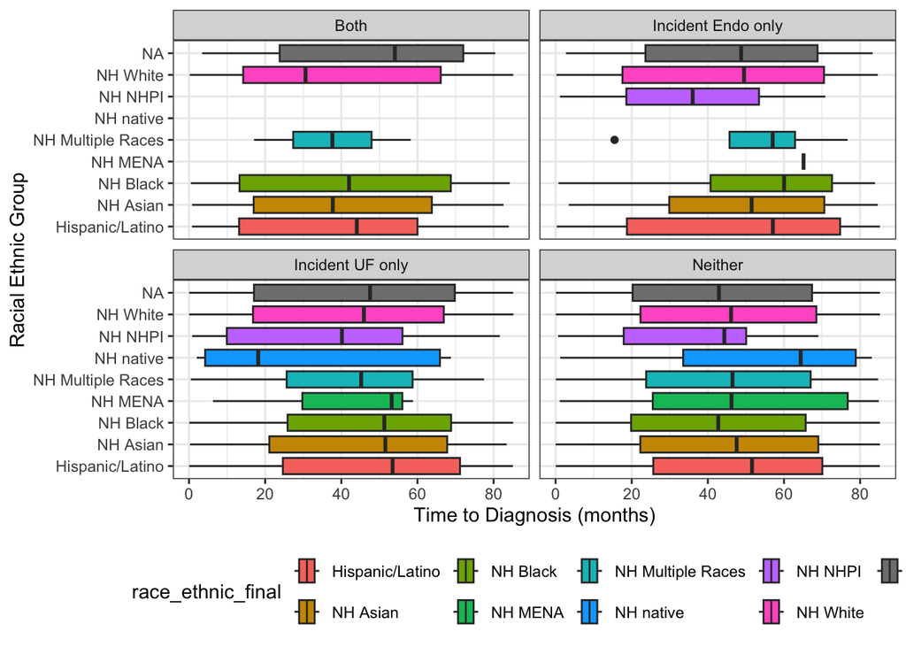

```r
ggplot(aes(x=time_to_dx, y=race_ethnic_final, fill=race_ethnic_final), data=ch2_final) +
  geom_boxplot() +
  ylab('Racial Ethnic Group') +
  xlab('Time to Diagnosis (months)') +
  facet_wrap(~final_outcome_group, nrow=2) +
  theme_bw() +
  theme(legend.position = 'bottom')
```

##### Among all patients

```r
summary(tableby(race_ethnic_final~time_to_dx, data=ch2_final,
                numeric.stats=c('Nmiss', 'N', 'meansd', 'median', 'q1q3')),
        labelTranslations = list(time_to_dx = 'Time to Dx or Censoring (months)'))
```

|  | Hispanic/Latino (N=6674) | NH Asian (N=1611) | NH Black (N=2840) | NH MENA (N=20) | NH Multiple Races (N=171) | NH native (N=29) | NH NHPI (N=16) | NH White (N=9515) | Total (N=20876) | p value |
| --- | --- | --- | --- | --- | --- | --- | --- | --- | --- | --- |
| **Time to Dx or Censoring (months)** |  |  |  |  |  |  |  |  |  | < 0.001 |
| N | 6674 | 1611 | 2840 | 20 | 171 | 29 | 16 | 9515 | 20876 |  |
| Mean (SD) | 47.527 (25.298) | 45.351 (25.721) | 43.649 (25.430) | 47.908 (28.207) | 43.611 (24.678) | 50.321 (29.725) | 35.648 (27.716) | 44.275 (25.585) | 45.313 (25.532) |  |
| Median | 51.767 | 47.833 | 45.400 | 54.750 | 46.467 | 61.400 | 42.250 | 46.000 | 48.067 |  |
| Q1, Q3 | 25.208, 70.292 | 22.183, 68.800 | 20.967, 66.908 | 25.542, 73.250 | 23.683, 64.367 | 23.600, 78.167 | 8.600, 55.667 | 21.733, 68.433 | 22.667, 68.867 |  |

##### Among those with a diagnosis

```r
summary(tableby(race_ethnic_final~time_to_dx, data=ch2_final %>% filter(final_censor_type =='Case'),
                numeric.stats=c('Nmiss', 'N', 'meansd', 'median', 'q1q3')),
        labelTranslations = list(time_to_dx = 'Time to Dx or Censoring (months)'))
```

|  | Hispanic/Latino (N=232) | NH Asian (N=41) | NH Black (N=128) | NH Multiple Races (N=8) | NH native (N=2) | NH NHPI (N=3) | NH White (N=257) | Total (N=671) | p value |
| --- | --- | --- | --- | --- | --- | --- | --- | --- | --- |
| **Time to Dx or Censoring (months)** |  |  |  |  |  |  |  |  | 0.114 |
| N | 232 | 41 | 128 | 8 | 2 | 3 | 257 | 671 |  |
| Mean (SD) | 16.075 (17.656) | 12.135 (13.490) | 13.877 (14.915) | 16.296 (17.140) | 3.133 (1.556) | 19.356 (31.793) | 12.015 (13.911) | 13.839 (15.629) |  |
| Median | 10.033 | 6.900 | 9.667 | 10.350 | 3.133 | 1.167 | 6.667 | 8.133 |  |
| Q1, Q3 | 1.533, 23.575 | 1.900, 17.600 | 2.225, 20.392 | 3.725, 26.367 | 2.583, 3.683 | 1.000, 28.617 | 1.200, 18.567 | 1.567, 20.500 |  |

#### By preferred language

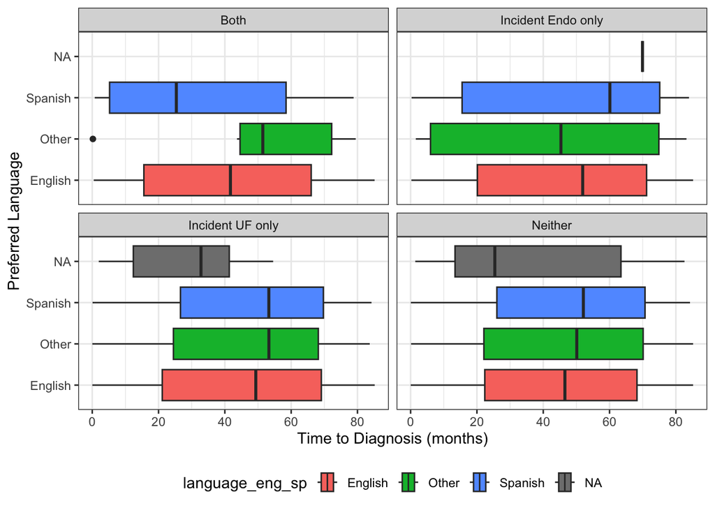

```r
ggplot(aes(x=time_to_dx, y=language_eng_sp, fill=language_eng_sp), data=ch2_final) +
  geom_boxplot() +
  ylab('Preferred Language') +
  xlab('Time to Diagnosis (months)') +
  facet_wrap(~final_outcome_group, nrow=2) +
  theme_bw() +
  theme(legend.position = 'bottom')
```

##### Among all patients

```r
summary(tableby(language_eng_sp~time_to_dx, data=ch2_final,
                numeric.stats=c('Nmiss', 'N', 'meansd', 'median', 'q1q3')),
        labelTranslations = list(time_to_dx = 'Time to Dx or Censoring (months)'))
```

|  | English (N=19511) | Other (N=719) | Spanish (N=2690) | Total (N=22920) | p value |
| --- | --- | --- | --- | --- | --- |
| **Time to Dx or Censoring (months)** |  |  |  |  | < 0.001 |
| N | 19511 | 719 | 2690 | 22920 |  |
| Mean (SD) | 44.718 (25.503) | 45.887 (26.221) | 48.012 (25.543) | 45.141 (25.551) |  |
| Median | 46.933 | 50.700 | 52.433 | 47.800 |  |
| Q1, Q3 | 22.133, 68.500 | 22.117, 70.200 | 25.800, 70.633 | 22.400, 68.800 |  |

##### Among those with a diagnosis

```r
summary(tableby(language_eng_sp~time_to_dx, data=ch2_final %>% filter(final_censor_type =='Case'),
                numeric.stats=c('Nmiss', 'N', 'meansd', 'median', 'q1q3')),
        labelTranslations = list(time_to_dx = 'Time to Dx or Censoring (months)'))
```

|  | English (N=623) | Other (N=16) | Spanish (N=100) | Total (N=739) | p value |
| --- | --- | --- | --- | --- | --- |
| **Time to Dx or Censoring (months)** |  |  |  |  | 0.253 |
| N | 623 | 16 | 100 | 739 |  |
| Mean (SD) | 13.471 (14.734) | 13.396 (19.142) | 16.240 (19.315) | 13.844 (15.536) |  |
| Median | 8.200 | 3.967 | 9.550 | 8.200 |  |
| Q1, Q3 | 1.633, 20.567 | 1.158, 15.475 | 1.367, 22.858 | 1.567, 20.633 |  |

### LTFU vs. not LTFU

Summary of observations – patients who were LTFU are/had:

- younger
- more likely to use HC
- more likely to be nulliparous
- more likely to be unpartnered
- lower BMI
- more likely to be at Manhattan/Westchester/Staten OP, least likely to be at FHC & Nassau OP
- more likely to be privately insured
- more likely to be a student
- more likely to be NH White
- more likely to be an English speaker
- less likely to receive an Adeno dx during FU

```r
ch2_final <- ch2_final %>% mutate(ltfu = case_when(final_censor_type == 'LTFU'~TRUE,
                                                   TRUE~FALSE))
# patient information
summary(tableby(ltfu~hcu_baseline+age_20160801+HC_status+parity_binary+marital_status_final+bmi_baseline+
                  adeno_fu + adeno_baseline,data=ch2_final), labelTranslations = pat_labs)
```

|  | FALSE (N=19476) | TRUE (N=3483) | Total (N=22959) | p value |
| --- | --- | --- | --- | --- |
| **Healthcare utilization (visits/baseline year)** |  |  |  | 0.003 |
| Mean (SD) | 4.514 (4.665) | 4.258 (4.828) | 4.476 (4.691) |  |
| Range | 1.000 - 128.000 | 1.000 - 108.000 | 1.000 - 128.000 |  |
| **Age (years)** |  |  |  | < 0.001 |
| Mean (SD) | 33.438 (9.011) | 30.681 (8.364) | 33.020 (8.970) |  |
| Range | 16.000 - 50.000 | 16.000 - 50.000 | 16.000 - 50.000 |  |
| **Hormonal contraceptive use** |  |  |  | < 0.001 |
| FALSE | 14928 (76.6%) | 2397 (68.8%) | 17325 (75.5%) |  |
| TRUE | 4548 (23.4%) | 1086 (31.2%) | 5634 (24.5%) |  |
| **Parity status** |  |  |  | < 0.001 |
| N-Miss | 4298 | 961 | 5259 |  |
| nulliparous | 7148 (47.1%) | 1501 (59.5%) | 8649 (48.9%) |  |
| parous | 8030 (52.9%) | 1021 (40.5%) | 9051 (51.1%) |  |
| **Relationship status** |  |  |  | < 0.001 |
| N-Miss | 948 | 223 | 1171 |  |
| Partnered | 7485 (40.4%) | 1081 (33.2%) | 8566 (39.3%) |  |
| Unpartnered | 11043 (59.6%) | 2179 (66.8%) | 13222 (60.7%) |  |
| **Body mass index (kg/m^2)** |  |  |  | < 0.001 |
| N-Miss | 994 | 191 | 1185 |  |
| Mean (SD) | 26.322 (5.444) | 25.250 (5.185) | 26.160 (5.419) |  |
| Range | 12.780 - 41.660 | 11.340 - 41.600 | 11.340 - 41.660 |  |
| **Adenomyosis dx during FU** |  |  |  | < 0.001 |
| FALSE | 19116 (98.2%) | 3468 (99.6%) | 22584 (98.4%) |  |
| TRUE | 360 (1.8%) | 15 (0.4%) | 375 (1.6%) |  |
| **Adenomyosis dx at baseline** |  |  |  | 0.181 |
| FALSE | 19466 (99.9%) | 3483 (100.0%) | 22949 (100.0%) |  |
| TRUE | 10 (0.1%) | 0 (0.0%) | 10 (0.0%) |  |

```r
# ses information
summary(tableby(ltfu~site_baseline+insur_status+employ_simple_final+race_ethnic_final+language_eng_sp,
                data=ch2_final), labelTranslations = ses_labs)
```

|  | FALSE (N=19476) | TRUE (N=3483) | Total (N=22959) | p value |
| --- | --- | --- | --- | --- |
| **Most common care site (baseline)** |  |  |  | < 0.001 |
| Brooklyn OP | 2246 (11.5%) | 375 (10.8%) | 2621 (11.4%) |  |
| Family Health Centers at NYU | 5189 (26.6%) | 641 (18.4%) | 5830 (25.4%) |  |
| Manhattan OP | 6581 (33.8%) | 1392 (40.0%) | 7973 (34.7%) |  |
| Nassau OP | 3393 (17.4%) | 418 (12.0%) | 3811 (16.6%) |  |
| NYU Langone Brooklyn | 279 (1.4%) | 44 (1.3%) | 323 (1.4%) |  |
| Queens OP | 927 (4.8%) | 127 (3.6%) | 1054 (4.6%) |  |
| Staten Island OP | 502 (2.6%) | 358 (10.3%) | 860 (3.7%) |  |
| Telemedicine | 9 (0.0%) | 1 (0.0%) | 10 (0.0%) |  |
| Tisch/Manhattan Inpatient | 229 (1.2%) | 45 (1.3%) | 274 (1.2%) |  |
| Westchester OP | 121 (0.6%) | 82 (2.4%) | 203 (0.9%) |  |
| **Insurance type** |  |  |  | < 0.001 |
| N-Miss | 1619 | 237 | 1856 |  |
| private | 11216 (62.8%) | 2168 (66.8%) | 13384 (63.4%) |  |
| public | 6641 (37.2%) | 1078 (33.2%) | 7719 (36.6%) |  |
| **Employment status** |  |  |  | < 0.001 |
| N-Miss | 4813 | 1453 | 6266 |  |
| Employed | 9961 (67.9%) | 1359 (66.9%) | 11320 (67.8%) |  |
| Not Employed | 3679 (25.1%) | 448 (22.1%) | 4127 (24.7%) |  |
| Retired | 19 (0.1%) | 3 (0.1%) | 22 (0.1%) |  |
| Student | 1004 (6.8%) | 220 (10.8%) | 1224 (7.3%) |  |
| **Racial and Ethnic Group** |  |  |  | < 0.001 |
| N-Miss | 1635 | 448 | 2083 |  |
| Hispanic/Latino | 6048 (33.9%) | 626 (20.6%) | 6674 (32.0%) |  |
| NH Asian | 1375 (7.7%) | 236 (7.8%) | 1611 (7.7%) |  |
| NH Black | 2437 (13.7%) | 403 (13.3%) | 2840 (13.6%) |  |
| NH MENA | 18 (0.1%) | 2 (0.1%) | 20 (0.1%) |  |
| NH Multiple Races | 146 (0.8%) | 25 (0.8%) | 171 (0.8%) |  |
| NH native | 23 (0.1%) | 6 (0.2%) | 29 (0.1%) |  |
| NH NHPI | 14 (0.1%) | 2 (0.1%) | 16 (0.1%) |  |
| NH White | 7780 (43.6%) | 1735 (57.2%) | 9515 (45.6%) |  |
| **Preferred language** |  |  |  | < 0.001 |
| N-Miss | 21 | 18 | 39 |  |
| English | 16390 (84.2%) | 3121 (90.1%) | 19511 (85.1%) |  |
| Other | 592 (3.0%) | 127 (3.7%) | 719 (3.1%) |  |
| Spanish | 2473 (12.7%) | 217 (6.3%) | 2690 (11.7%) |  |

## Exploratory descriptive statistics

### Table 1 for OBGYN care cohort

Compared to the larger cohort, the OBGYN cohort is/has:

- lower HCU at baseline
- younger
- more HC use
- more nulliparity
- lower BMI
- more likely to be at Nassau/State Island OP and less likely to be at FHC
- more likely to have private insurance
- less likely to be student
- more likely to be NH White, less likely to be Hispanic/NH Black
- more likely to be English speaking

```r
summary(tableby(obgyn_care_cohort~hcu_baseline+age_20160801+HC_status+parity_binary+
                  marital_status_final+bmi_baseline+site_baseline+insur_status+employ_simple_final+
                  race_ethnic_final+language_eng_sp+adeno_fu + adeno_baseline, data=ch2_final),
        labelTranslations = c(pat_labs, ses_labs))
```

|  | FALSE (N=13776) | TRUE (N=9183) | Total (N=22959) | p value |
| --- | --- | --- | --- | --- |
| **Healthcare utilization (visits/baseline year)** |  |  |  | < 0.001 |
| Mean (SD) | 4.668 (4.673) | 4.188 (4.702) | 4.476 (4.691) |  |
| Range | 1.000 - 128.000 | 1.000 - 46.000 | 1.000 - 128.000 |  |
| **Age (years)** |  |  |  | < 0.001 |
| Mean (SD) | 33.724 (9.048) | 31.964 (8.747) | 33.020 (8.970) |  |
| Range | 16.000 - 50.000 | 16.000 - 50.000 | 16.000 - 50.000 |  |
| **Hormonal contraceptive use** |  |  |  | < 0.001 |
| FALSE | 11322 (82.2%) | 6003 (65.4%) | 17325 (75.5%) |  |
| TRUE | 2454 (17.8%) | 3180 (34.6%) | 5634 (24.5%) |  |
| **Parity status** |  |  |  | < 0.001 |
| N-Miss | 4118 | 1141 | 5259 |  |
| nulliparous | 4594 (47.6%) | 4055 (50.4%) | 8649 (48.9%) |  |
| parous | 5064 (52.4%) | 3987 (49.6%) | 9051 (51.1%) |  |
| **Relationship status** |  |  |  | 0.874 |
| N-Miss | 660 | 511 | 1171 |  |
| Partnered | 5151 (39.3%) | 3415 (39.4%) | 8566 (39.3%) |  |
| Unpartnered | 7965 (60.7%) | 5257 (60.6%) | 13222 (60.7%) |  |
| **Body mass index (kg/m^2)** |  |  |  | < 0.001 |
| N-Miss | 752 | 433 | 1185 |  |
| Mean (SD) | 26.471 (5.592) | 25.698 (5.117) | 26.160 (5.419) |  |
| Range | 11.340 - 41.660 | 14.360 - 41.660 | 11.340 - 41.660 |  |
| **Most common care site (baseline)** |  |  |  | < 0.001 |
| Brooklyn OP | 1734 (12.6%) | 887 (9.7%) | 2621 (11.4%) |  |
| Family Health Centers at NYU | 4057 (29.4%) | 1773 (19.3%) | 5830 (25.4%) |  |
| Manhattan OP | 4776 (34.7%) | 3197 (34.8%) | 7973 (34.7%) |  |
| Nassau OP | 1540 (11.2%) | 2271 (24.7%) | 3811 (16.6%) |  |
| NYU Langone Brooklyn | 254 (1.8%) | 69 (0.8%) | 323 (1.4%) |  |
| Queens OP | 913 (6.6%) | 141 (1.5%) | 1054 (4.6%) |  |
| Staten Island OP | 69 (0.5%) | 791 (8.6%) | 860 (3.7%) |  |
| Telemedicine | 10 (0.1%) | 0 (0.0%) | 10 (0.0%) |  |
| Tisch/Manhattan Inpatient | 220 (1.6%) | 54 (0.6%) | 274 (1.2%) |  |
| Westchester OP | 203 (1.5%) | 0 (0.0%) | 203 (0.9%) |  |
| **Insurance type** |  |  |  | < 0.001 |
| N-Miss | 1280 | 576 | 1856 |  |
| private | 7399 (59.2%) | 5985 (69.5%) | 13384 (63.4%) |  |
| public | 5097 (40.8%) | 2622 (30.5%) | 7719 (36.6%) |  |
| **Employment status** |  |  |  | < 0.001 |
| N-Miss | 3001 | 3265 | 6266 |  |
| Employed | 7224 (67.0%) | 4096 (69.2%) | 11320 (67.8%) |  |
| Not Employed | 2629 (24.4%) | 1498 (25.3%) | 4127 (24.7%) |  |
| Retired | 16 (0.1%) | 6 (0.1%) | 22 (0.1%) |  |
| Student | 906 (8.4%) | 318 (5.4%) | 1224 (7.3%) |  |
| **Racial and Ethnic Group** |  |  |  | < 0.001 |
| N-Miss | 1284 | 799 | 2083 |  |
| Hispanic/Latino | 4425 (35.4%) | 2249 (26.8%) | 6674 (32.0%) |  |
| NH Asian | 1123 (9.0%) | 488 (5.8%) | 1611 (7.7%) |  |
| NH Black | 1977 (15.8%) | 863 (10.3%) | 2840 (13.6%) |  |
| NH MENA | 13 (0.1%) | 7 (0.1%) | 20 (0.1%) |  |
| NH Multiple Races | 106 (0.8%) | 65 (0.8%) | 171 (0.8%) |  |
| NH native | 16 (0.1%) | 13 (0.2%) | 29 (0.1%) |  |
| NH NHPI | 9 (0.1%) | 7 (0.1%) | 16 (0.1%) |  |
| NH White | 4823 (38.6%) | 4692 (56.0%) | 9515 (45.6%) |  |
| **Preferred language** |  |  |  | < 0.001 |
| N-Miss | 20 | 19 | 39 |  |
| English | 11418 (83.0%) | 8093 (88.3%) | 19511 (85.1%) |  |
| Other | 587 (4.3%) | 132 (1.4%) | 719 (3.1%) |  |
| Spanish | 1751 (12.7%) | 939 (10.2%) | 2690 (11.7%) |  |
| **Adenomyosis dx during FU** |  |  |  | 0.670 |
| FALSE | 13555 (98.4%) | 9029 (98.3%) | 22584 (98.4%) |  |
| TRUE | 221 (1.6%) | 154 (1.7%) | 375 (1.6%) |  |
| **Adenomyosis dx at baseline** |  |  |  | 0.518 |
| FALSE | 13771 (100.0%) | 9178 (99.9%) | 22949 (100.0%) |  |
| TRUE | 5 (0.0%) | 5 (0.1%) | 10 (0.0%) |  |

### Table 1 for all cases

```r
ch2_all_cases <- ttd_symptoms_all_cases %>%
  select(pat_id, contains('uf'), contains('endo'), final_outcome_status_all, final_censor_date_all,
         final_censor_type_all, contains('symptom'), contains('ttd')) %>%
  rename(time_to_dx = ttd,
         time_to_dx_2symptoms = ttd_2) %>%
  # remove if not disease free at baseline
  filter(!pat_id %in% confident_prevalents$pat_id) %>%
  # remove if they do not live in NY-Newark CSA? %>%
  filter(!pat_id %in% not_in_nyc$pat_id) %>%
  left_join(pat_w_covars, by='pat_id') %>%
  mutate(symptom_group = case_when(grepl('R10.2|F52.6|N94.1|N94.0|M54.5', first_symptom_icd10s)~'Pain',
                                  grepl('N94.[4-6]|N93.0|N93.8|N93.9|N92.0|N92.1|D50.0',
                                             first_symptom_icd10s)~'Menstrual/Bleeding',
                                  grepl('N83.0|N83.2|N73.9', first_symptom_icd10s)~'PID/Ovarian cysts',
                                  grepl('N97.9', first_symptom_icd10s)~'Infertility',
                                  grepl('N32.9|K59.00|N39.3|R19.7', first_symptom_icd10s)~
                                    'Other Genito-urinary')) %>%
  mutate(final_outcome_group = case_when(grepl('Both', final_outcome_status_all)~'Both',
                                         TRUE~final_outcome_status_all))
```

There are no notable differences between the all cases cohort and the confident cases cohort.

```r
# patient information
summary(tableby(~hcu_baseline + age_20160801 + HC_status + parity_binary +
                  marital_status_final + bmi_baseline + site_baseline + insur_status +
                  employ_simple_final + race_ethnic_final + language_eng_sp + adeno_fu + adeno_baseline,
                data=ch2_all_cases), labelTranslations = c(pat_labs, ses_labs))
```

|  | Overall (N=23348) |
| --- | --- |
| **Healthcare utilization (visits/baseline year)** |  |
| Mean (SD) | 4.468 (4.679) |
| Range | 1.000 - 128.000 |
| **Age (years)** |  |
| Mean (SD) | 33.084 (8.966) |
| Range | 16.000 - 50.000 |
| **Hormonal contraceptive use** |  |
| FALSE | 17657 (75.6%) |
| TRUE | 5691 (24.4%) |
| **Parity status** |  |
| N-Miss | 5390 |
| nulliparous | 8766 (48.8%) |
| parous | 9192 (51.2%) |
| **Relationship status** |  |
| N-Miss | 1197 |
| Partnered | 8720 (39.4%) |
| Unpartnered | 13431 (60.6%) |
| **Body mass index (kg/m^2)** |  |
| N-Miss | 1211 |
| Mean (SD) | 26.177 (5.423) |
| Range | 11.340 - 41.660 |
| **Most common care site (baseline)** |  |
| Brooklyn OP | 2670 (11.4%) |
| Family Health Centers at NYU | 5905 (25.3%) |
| Manhattan OP | 8106 (34.7%) |
| Nassau OP | 3883 (16.6%) |
| NYU Langone Brooklyn | 325 (1.4%) |
| Queens OP | 1094 (4.7%) |
| Staten Island OP | 868 (3.7%) |
| Telemedicine | 10 (0.0%) |
| Tisch/Manhattan Inpatient | 281 (1.2%) |
| Westchester OP | 206 (0.9%) |
| **Insurance type** |  |
| N-Miss | 1878 |
| private | 13641 (63.5%) |
| public | 7829 (36.5%) |
| **Employment status** |  |
| N-Miss | 6374 |
| Employed | 11542 (68.0%) |
| Not Employed | 4170 (24.6%) |
| Retired | 22 (0.1%) |
| Student | 1240 (7.3%) |
| **Racial and Ethnic Group** |  |
| N-Miss | 2121 |
| Hispanic/Latino | 6758 (31.8%) |
| NH Asian | 1634 (7.7%) |
| NH Black | 2939 (13.8%) |
| NH MENA | 20 (0.1%) |
| NH Multiple Races | 173 (0.8%) |
| NH native | 29 (0.1%) |
| NH NHPI | 16 (0.1%) |
| NH White | 9658 (45.5%) |
| **Preferred language** |  |
| N-Miss | 40 |
| English | 19865 (85.2%) |
| Other | 733 (3.1%) |
| Spanish | 2710 (11.6%) |
| **Adenomyosis dx during FU** |  |
| FALSE | 22970 (98.4%) |
| TRUE | 378 (1.6%) |
| **Adenomyosis dx at baseline** |  |
| FALSE | 23338 (100.0%) |
| TRUE | 10 (0.0%) |